# 1.2.MPQ.Exploratory.Plots

Kevin Bruce

07/10/2020

# Exploratory plots for MPQ data ranging from 2015 - 2019

## Introduction

Kiritimati Research Project- PPQ complexity analyses 2015 - 2019

PPQ = Permanent Photoquadrat (16m2)

This document is for the PPQ data collected on Kiritimati to look at complexity changes that occur on reefs following a mass mortality event.

The plots below show a view of the data across different spatial and temporal scales. We will start by looking at the data broadly before zooming in to specific PPQ fluctuations over time.

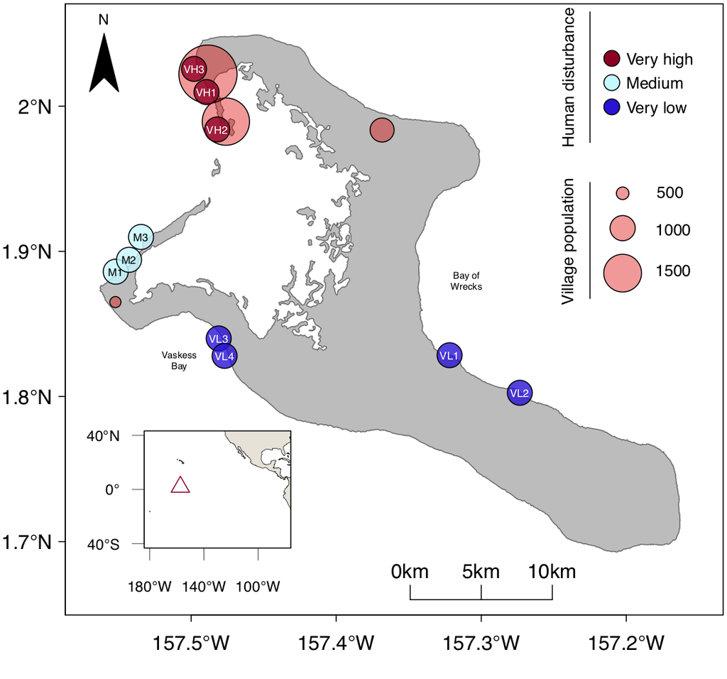

## Site data available

Below is a table indicating the various sites around Kiritimati and how many MPQ’s were sampled during each expedition

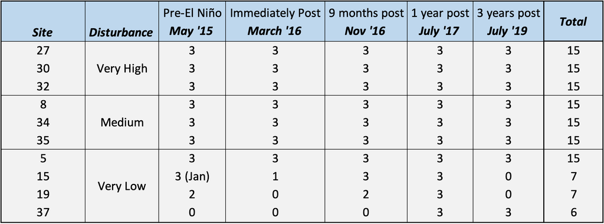

## The 6 complexity metrics collected from each MPQ

1. Habitat Volumetric Change
2. Surface complexity
3. Terrain Ruggedness (VRM)
4. Slope
5. Profile Curvature
6. Planform Curvature

# 1. Habitat Volumetric Change

- Volumetric change between 2015-2017 and 2015-2019 was quantified in CloudCompare, with the volume change (VC) between 2017 - 2019 calculated algebraically from the equation below for all sites except 37, which was initially sampled in 2017.

**2017 - 2019 VC = (2015-2019 VC) - (2015-2017 VC)**

## Volumetric Change at each of the three timepoints

*Statistical Results:*

- The 2017-2019 timepoint is significantly different from the 2015-2017 timepoint (however not from 2015-2019)- via ANOVA.

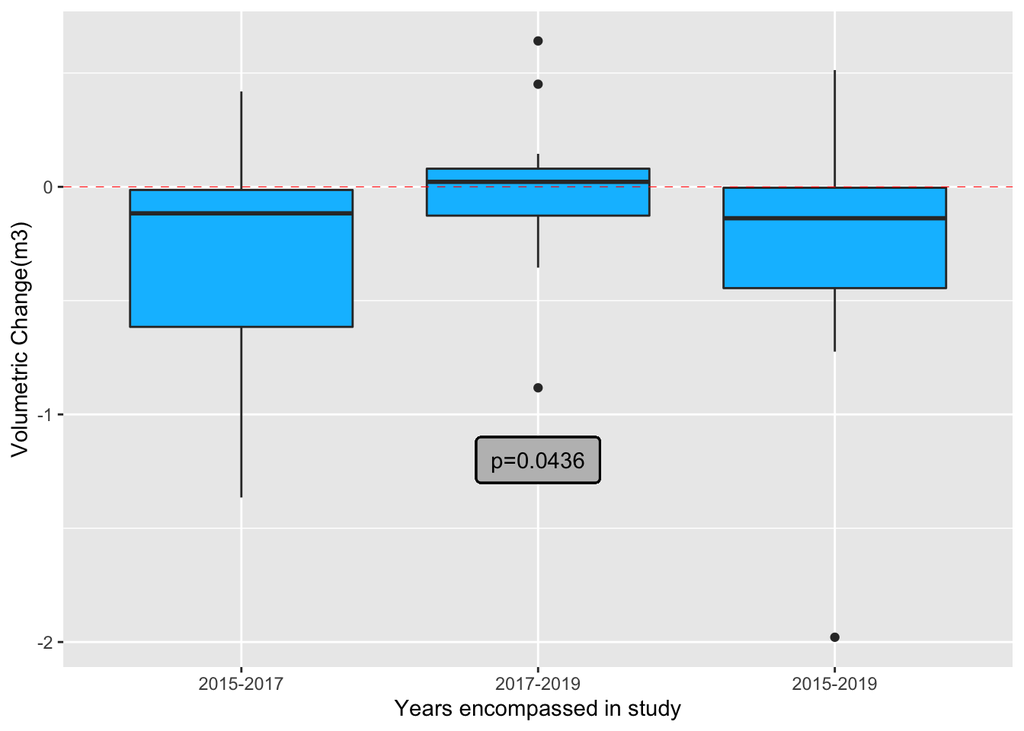

## 2-year increment volumetric change

- An extremely similar plot to the one above, however this one breaks down the volume change into 2-year increments.
- Significantly (T-test) difference in volumetric change between the 2015-2017 and 2017-2019 timepoints.
- Larger variation in the initial years of the study

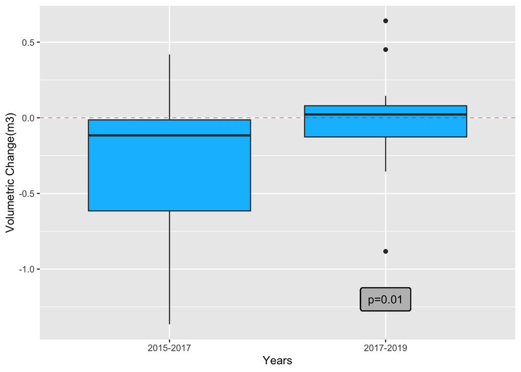

## Volumetric Change ~ Human Disturbance

- Lowered volumetric loss in the latter timepoint occurred in both Very Low and Very High disturbance levels
- However, rubble transport is extremely high at the Very High sites, so this result needs to be taken with a grain of salt
- Medium disturbance sites experienced very limited volumetric change at either timepoint
- This is believed to be the case due to a large storm in January 2015 destroying most of the more “complex” corals (primarily branching and foliose) and in removing those form the reef, left the less-complex, massive and submassive structure which is harder to erode and/or degrades slower

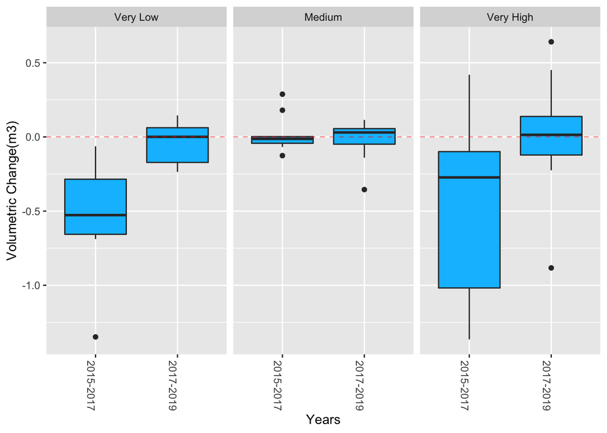

## Volumetric Change ~ Region

This plot is to highlight two facts: 1. There is no data in the latter timepoint from BOW 2. Vaskes Bay appears to “increase” in volume, however we delve into that further in the next plot

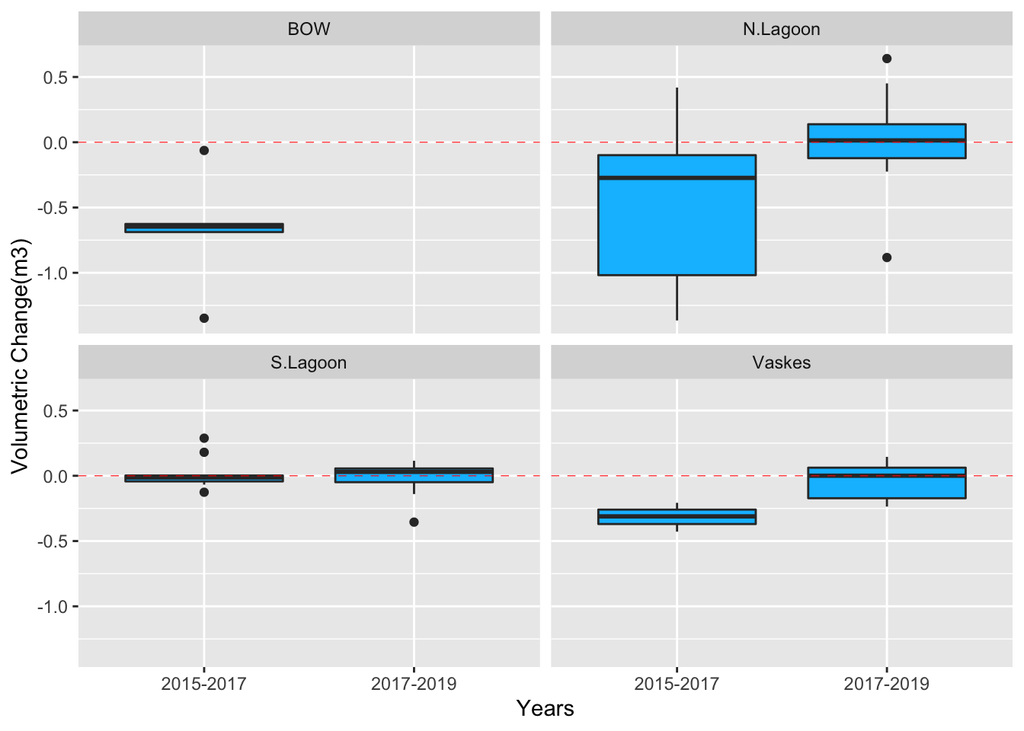

## Vaskes Bay

- Both site 5 and 37 are located in Vaskes bay is on the southern edge of the atoll (with the other VL sites in the BOW on a more north-eastern facing bay)
- Only site 5 was sampled in 2015, with site 37 first sampled was 2017
- To investigate whether these two sites are similar I plotted them together (bottom) and only site 5 (top)
- Site 37 evidently experienced more of an increase in habitat volume as it pulls the average volumetric change up (bottom plot)

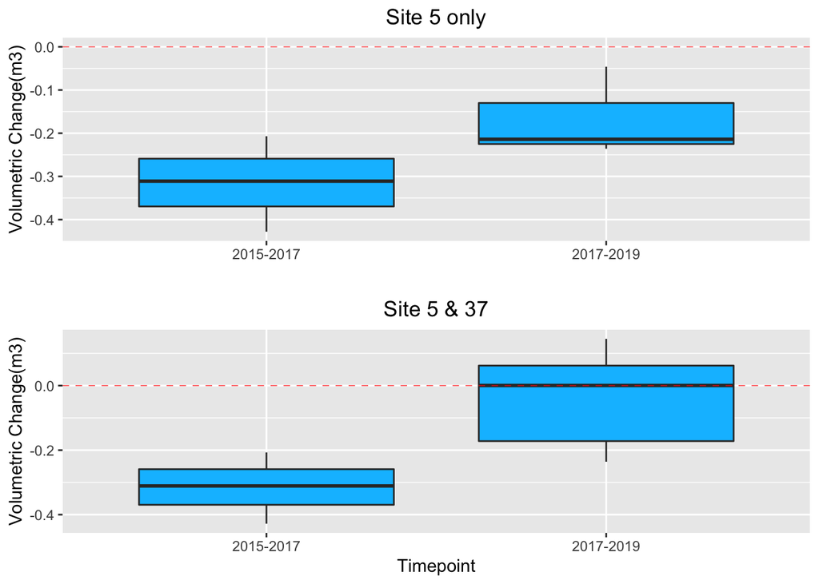

# 2. ArcMap Complexity

#### 2.1 Plot size through time

- Plot size had been shown to vary over time in previous exploratory plots
- This issue has been fixed now by copying previous plot areas in ArcMap and importing them into subsequent years plots before orienting them on consistent stake and benthic topography

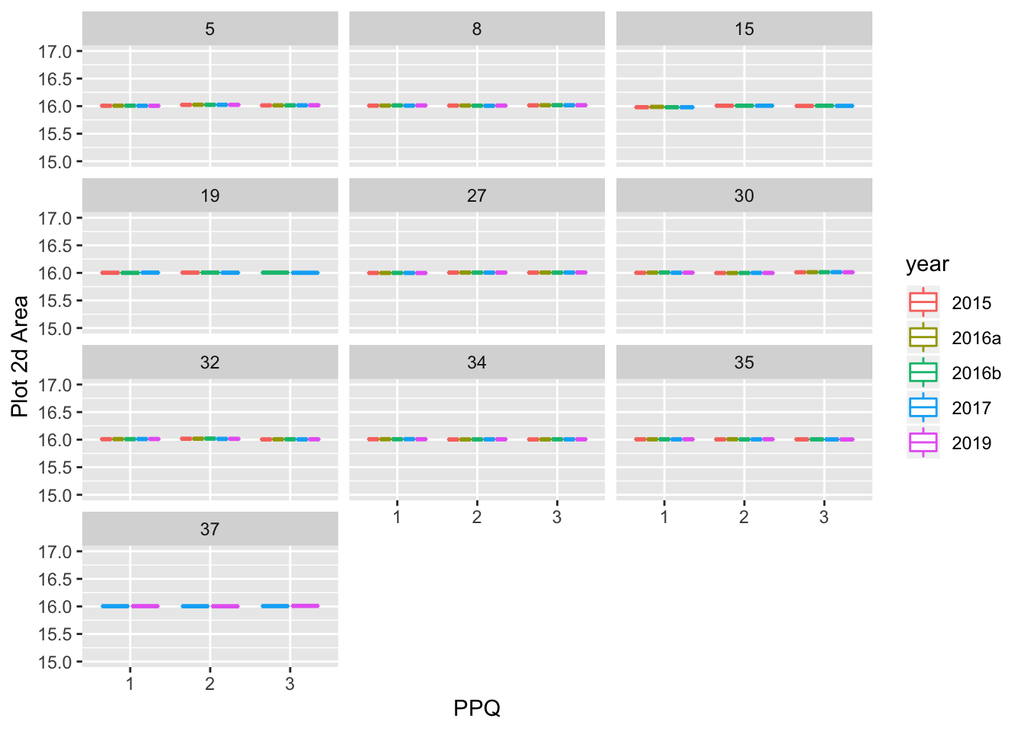

# 3 Complexity Metrics ~ Year

-Overarching theme for most metrics: After a large initial declines occurred at the tail end/immediately following the mass mortality event (2016a) and then complexity stayed consistent through time

- All statistical results in this section were computed via ANOVA and TukeyHSD tests (modelling to come)

## 3.1 Surface Complexity

- Significant differences occurred at the 1cm DEM, yet were lost in later DEM resolutions
- At the 1cm, the 2015 timepoint is significantly different from 2016a, 2016b, and 2017 timepoints

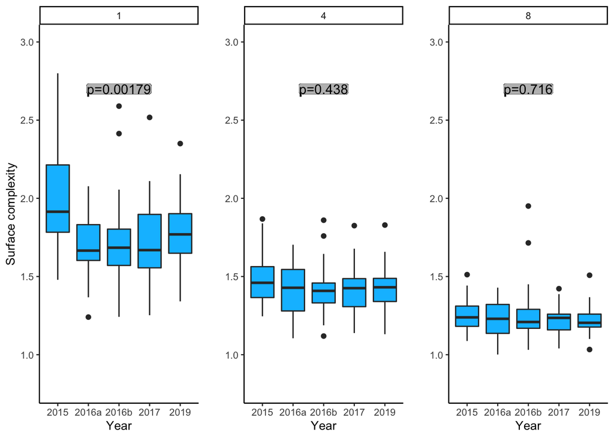

## 3.2 Slope

- Initial decline between 2015 and 2016a seen here
- Only significant difference occurs at 1cm DEM between 2015 and 2016a timepoints

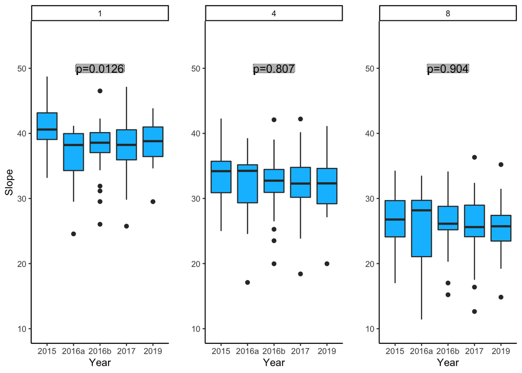

## 3.3 VRM

- Steep initial decline apparent between 2015 and 2016a timepoints, with 2019 appearing to rebound to similar 2015 levels at 1cm DEM.
- Above trend is less apparent and/or disappears at larger DEM resolutions
- At 1cm DEM, 2015 timepoint is significantly different from 2016a, 2016b, and 2017 (almost 2019 (P= 0.05397)). 2019 timepoint significantly different from 2016a, 2016b, and 2017.

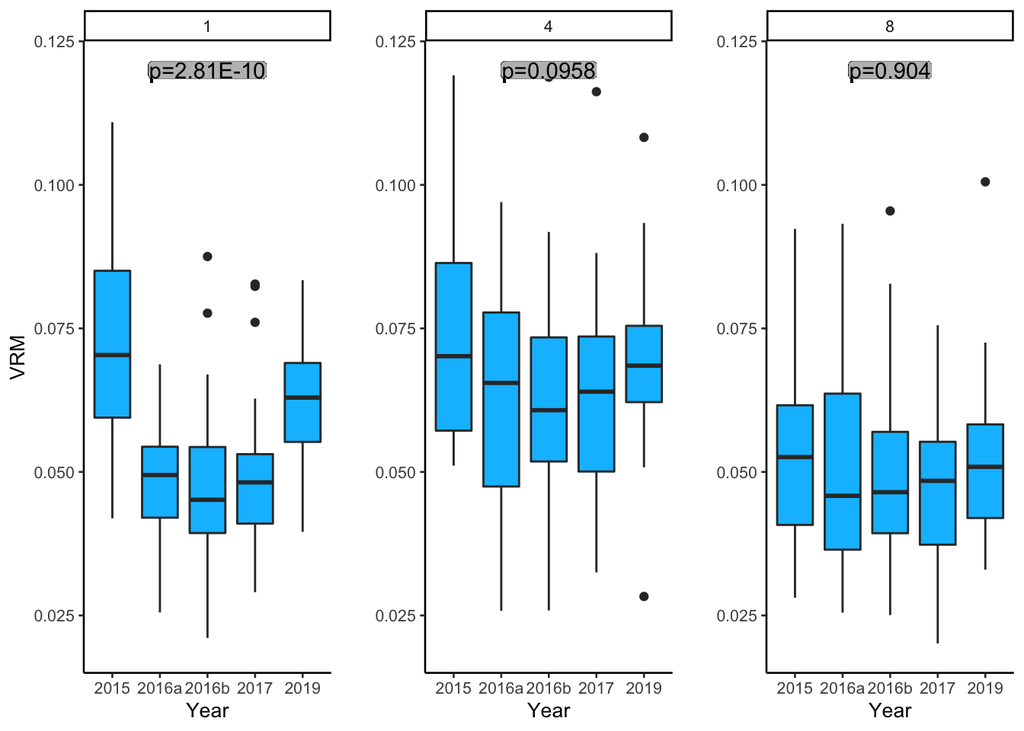

## 3.4 Profile Curvature

- Trend of profile curvature shifting from more negative towards more positive values through time, indicating shifts in structure orientation to more inwardly concave (positive pro.curv values).
- I hypothesis this is due to erosion, as profile curvature deals with the orientation at the point of maximum slope and therefore that is where I believe the flow of water and eroded debris would be moving the strongest.
- Magnitude differs across resolutions, but the trend appears to stay consistent across DEM resolutions.

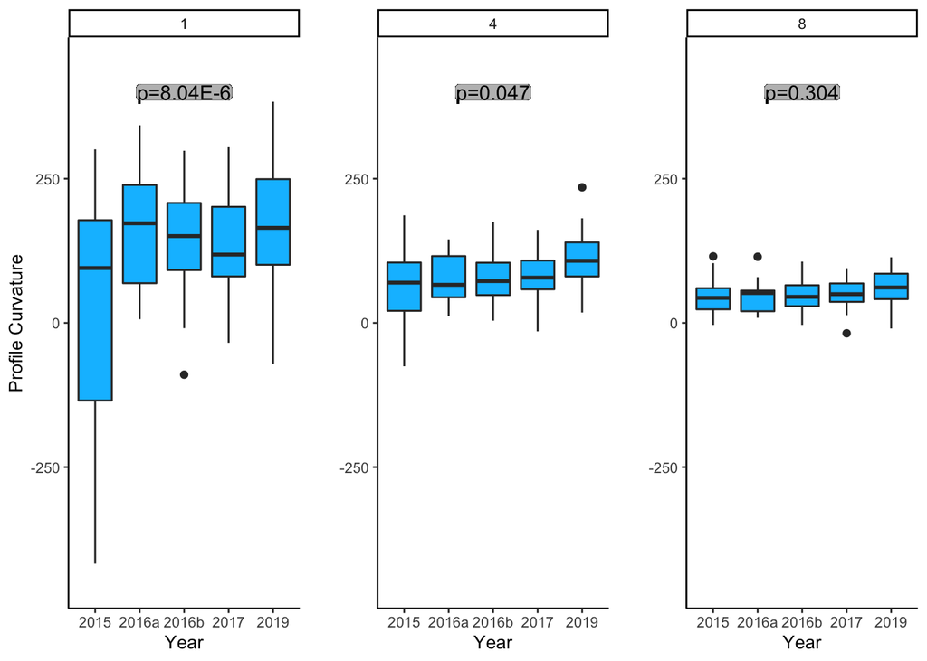

## 3.5 Planform Curvature

- Similar to profile curvature, planform curvature values move towards more positive values as we progress through time, indicating the structure’s orientation perpendicular to the maximum slope is becoming more outwardly convex.
- This could again be due to erosion forces, as these heavily erode the face of the maximum slope, thereby leaving lips or ridges directly perpendicular to the flow.
- Again, this trend is present across DEM resolutions.

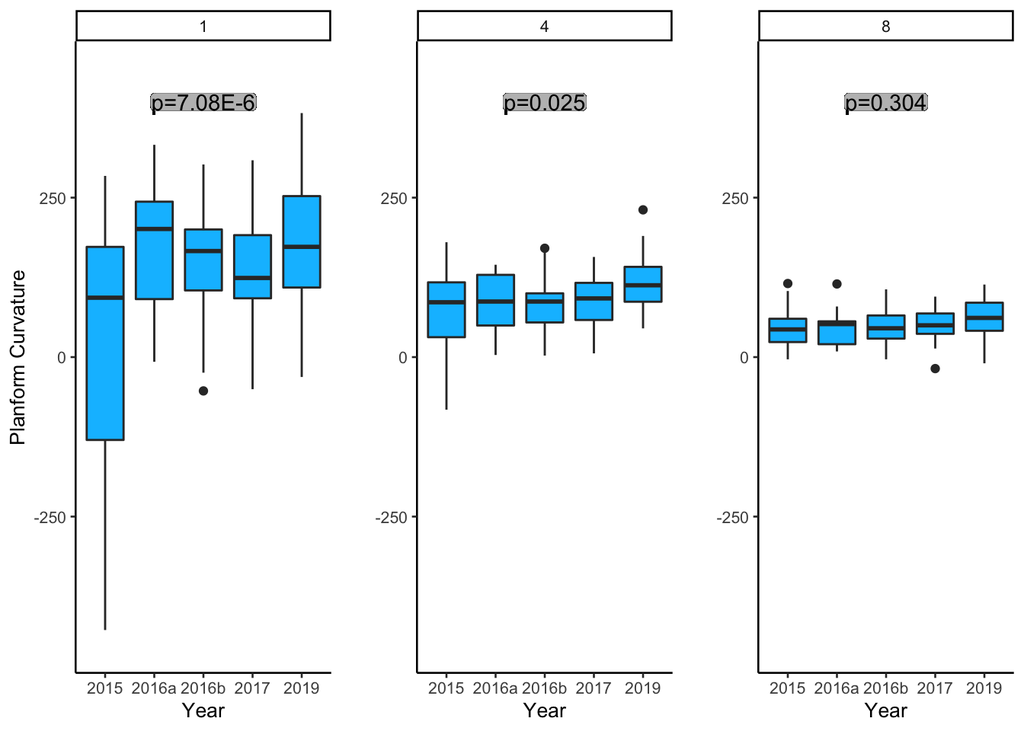

# 4. Complexity Metrics Across the Human Disturbance gradient

## 4.1 Surface Complexity ~ Human Disturbance

- All disturbance levels experienced their largest declines between 2015 and 2016a, with Very Low sites experiencing the largest losses.

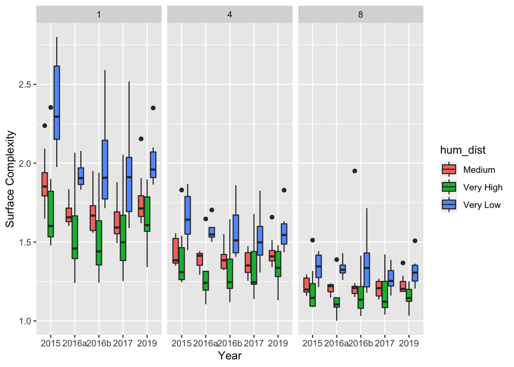

## 4.2 Slope ~ Human Disturbance

- Similar results to Surface Complexity.

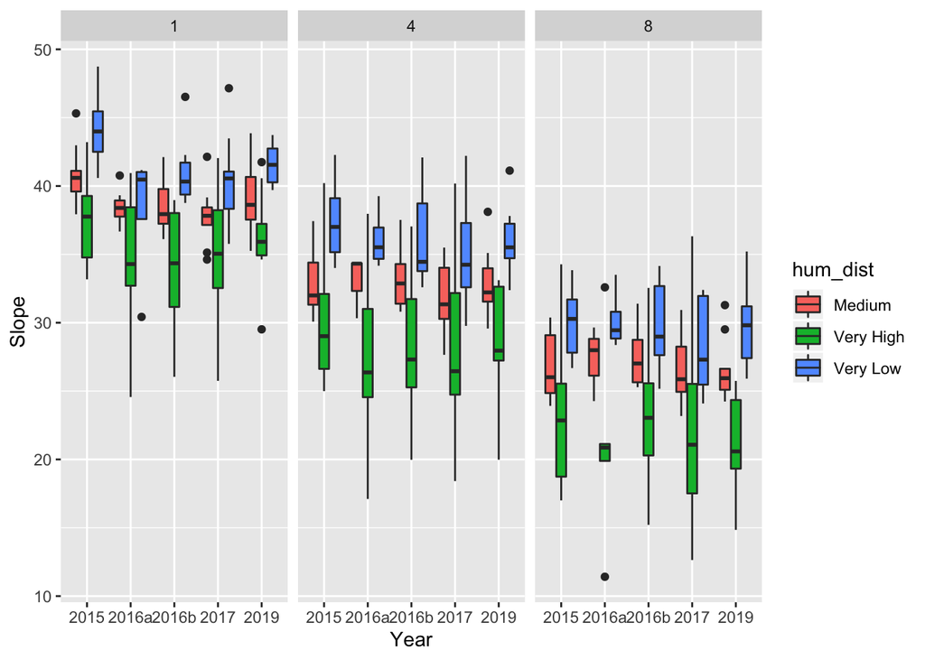

## 4.3 VRM ~ Human Disturbance

- Those initial losses at all disturbance levels are more pronounced with VRM than any other metric

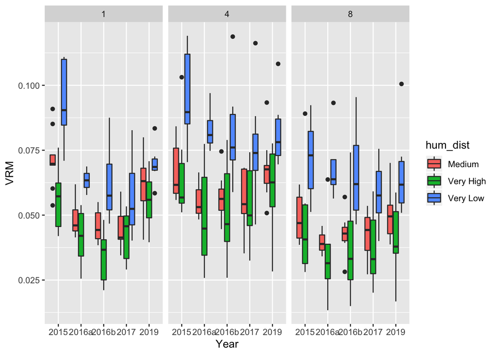

## 4.4 Profile Curvature ~ Human Disturbance

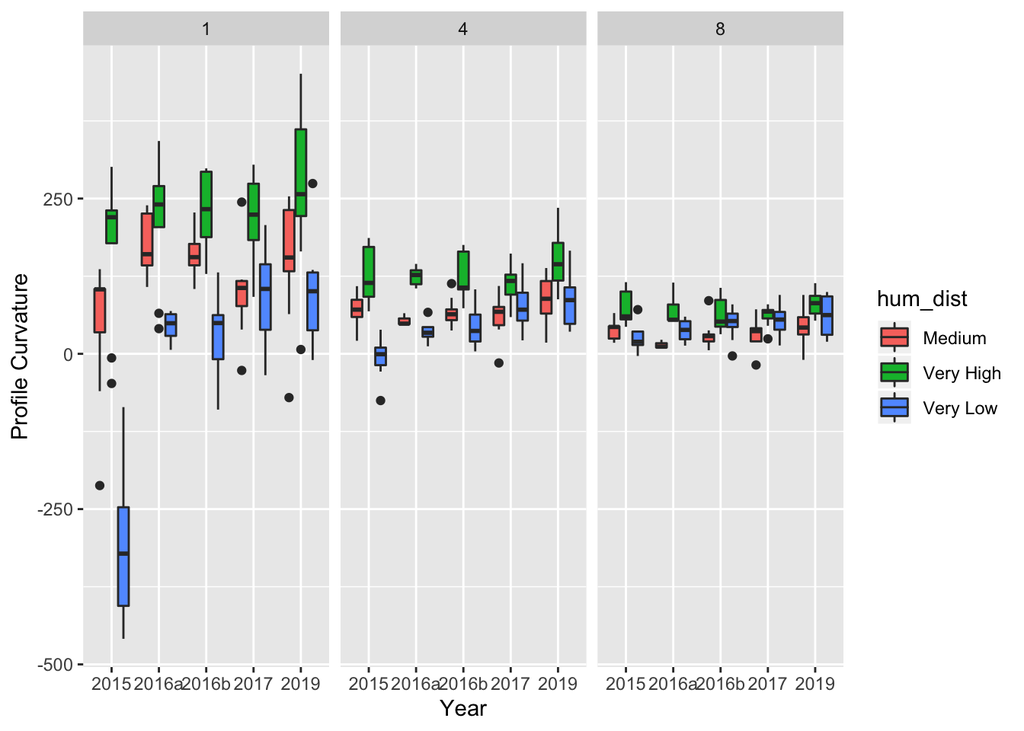

## 4.5 Planform Curvature ~ Human Disturbance

- Similar results to profile curvature
- Change in orientation of structure perpendicular to maximum slope seen across disturbance levels, although is most pronounced at Very Low sites, which are likely driving the overall trend reported earlier.

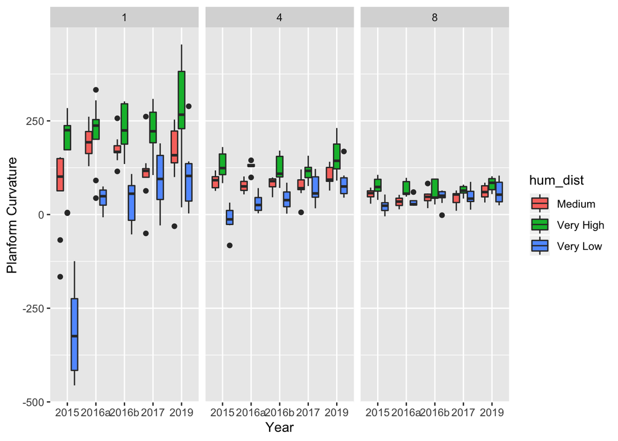

# 5. Complexity Metrics by geographic region

- This section is to highlight differences between the regions that make up the Very Low disturbance level: Bay of Wrecks & Vaskes Bay.
- Overall, Bay of Wrecks was more structurally complex than the Vaskes Bay sites.
- When looking at certain metrics (ex: VRM) it appears Vaskes Bay sites are more similar structurally to the Medium disturbance sites than to the BOW sites after the El Nino.
- I believe this is due to the different coral communities present at the two sites, so this will be worth looking at in more detail with the morphological digitization work.

## 5.1 Surface Complexity ~ Region

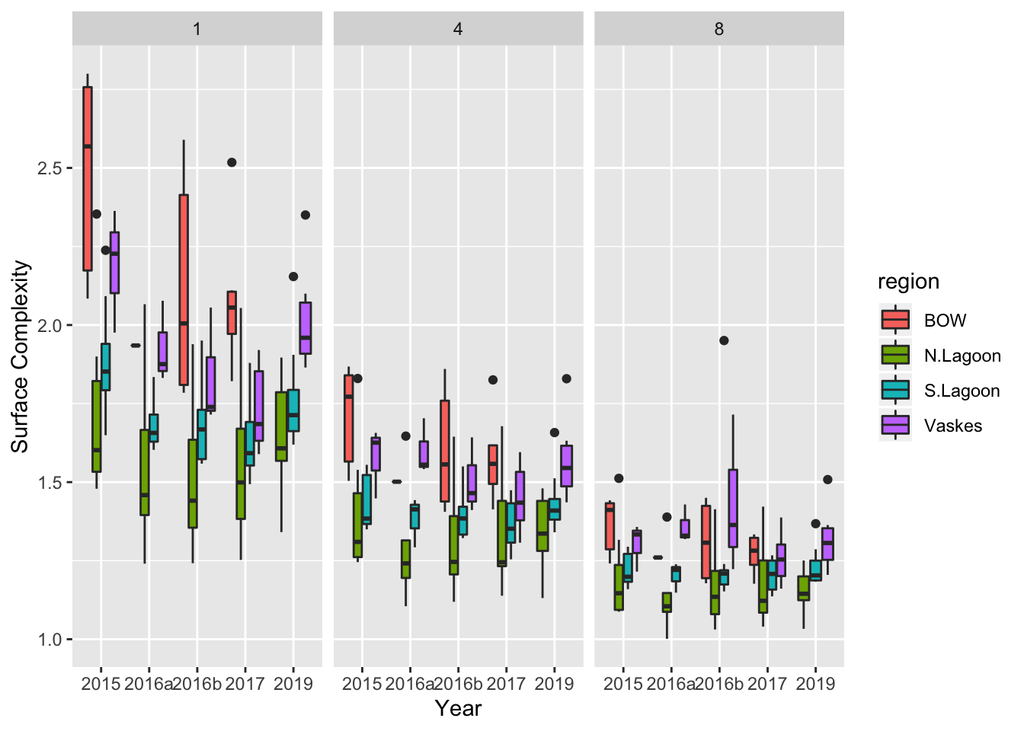

## 5.2 Slope ~ Region

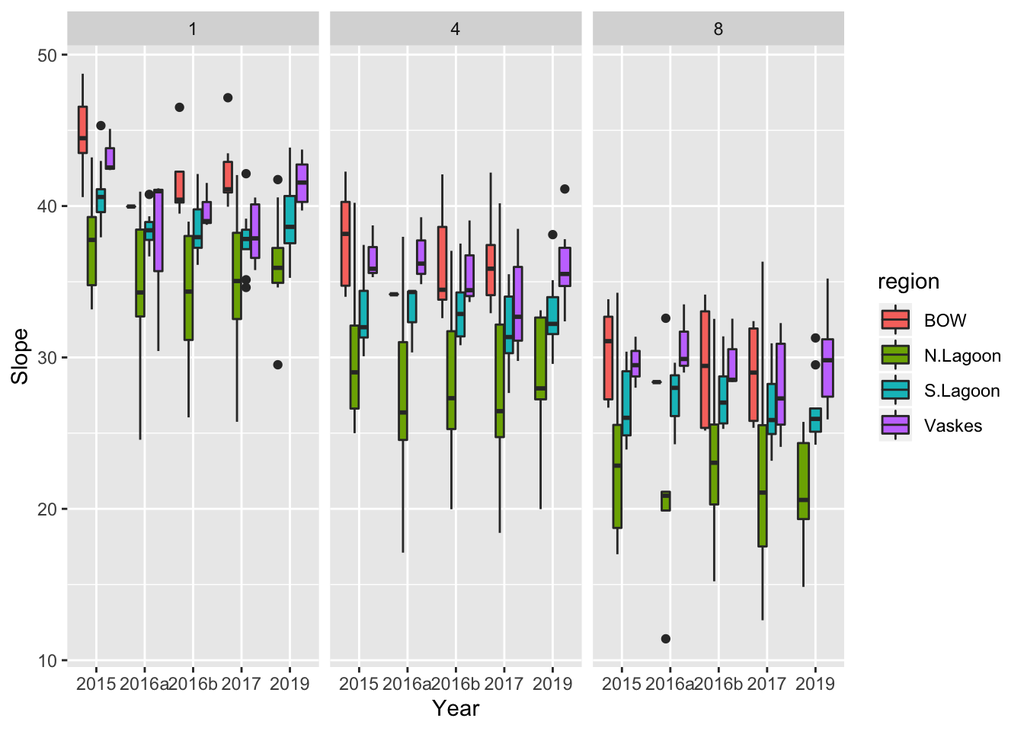

## 5.3 VRM ~ Region

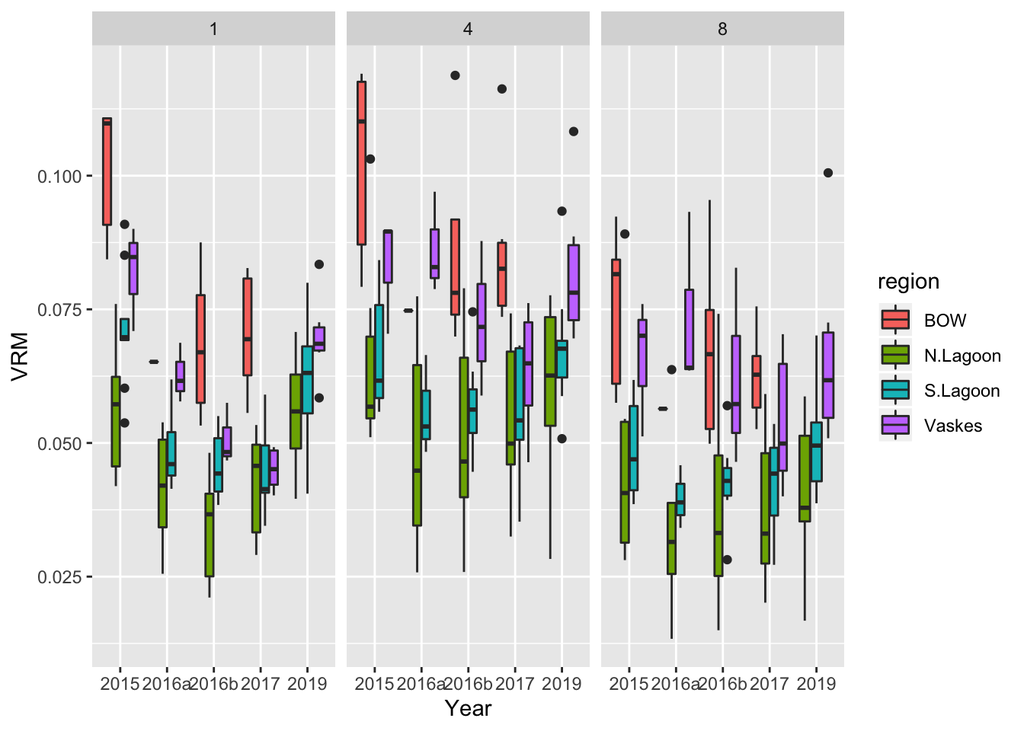

## 5.4 Profile Curvature ~ Region

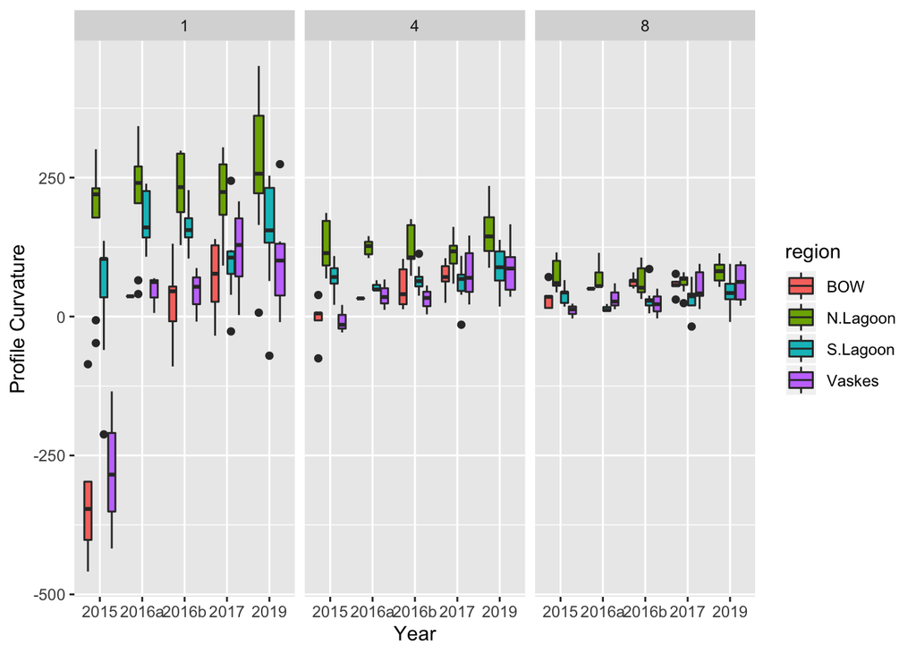

## 5.5 Planform Curvature ~ Region

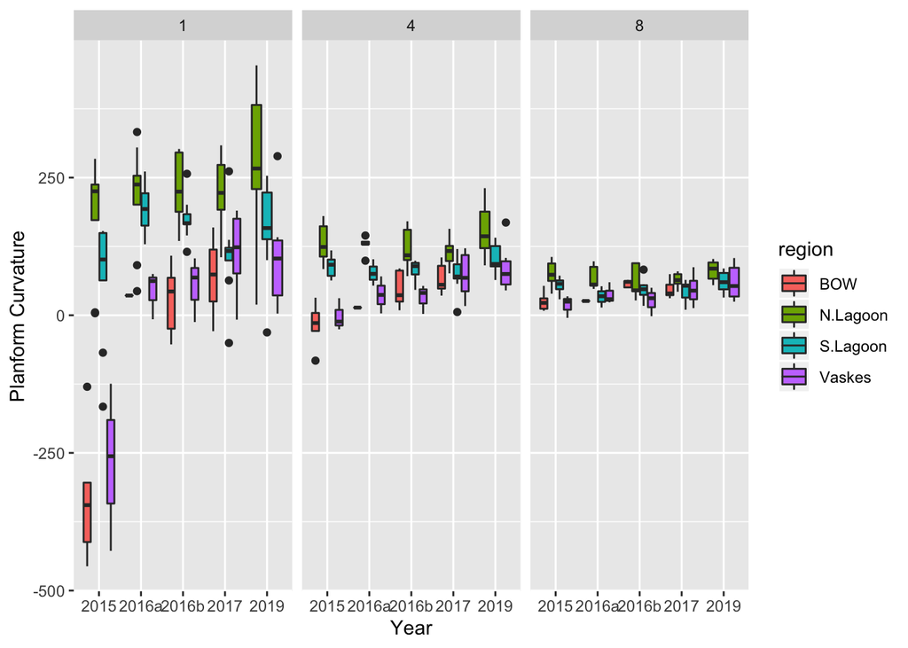

# 6. ArcMap Digitization

```r
# dig_sum
#
# #Check the levels of how the bars will show up on the stacked barchart
# levels(as.factor(dig_sum$Benthic_Morphology))
#
# #Re-Structure bar charts
# dig_sum$Benthic_Morphology <- factor(dig_sum$Benthic_Morphology, levels= c("Live_Branching", "Live_Columnar", "Live_Digitate", "Live_Encrusting", "Live_Encrusting_Columnar", "Live_Foliose", "Live_FreeLiving", "Live_Massive", "Live_Massive_Grooved", "Live_Porites", "Live_SubMassive", "Live_Tabulate", "SoftCoral_Nodular", "SoftCoral_Plating", "NonCoral_Branching", "NonCoral_Encrusting", "NonCoral_Massive", "NonCoral_SubMassive", "Macroalgae", "Dead_Branching", "Dead_Columnar", "Dead_Foliose", "Dead_Massive", "Dead_Tabulate", "Dead_SoftCoral", "Rubble", "Sand"))
#
#
# p1 <- ggplot(dig_sum, aes(y=Per_Area, x=year.site.ppq, fill= Benthic_Morphology)) + geom_bar(stat = 'identity', position = 'stack') + morph.colscale +theme(axis.text.x = element_text(angle = 270, vjust = 0.5, hjust=1) +  geom_vline(xintercept = 26.5, linetype="dashed", color="black", size=0.5)) + geom_vline(xintercept = 45.5, linetype="dashed", color="black", size=0.5) + geom_vline(xintercept = 32.5, linetype="dashed", color="black", size=0.5)+ scale_color_manual(values = c("Dead_Branching" = "grey69", "Dead_Columnar" = "grey68", "Dead_Foliose" ="grey67", "Dead_Massive"="grey66", "Dead_Tabulate"="grey65", "Dead_SoftCoral"="grey40", "Rubble"= "grey30", "Sand"="grey20"))
# p1
#
#
#
#
#
#
# # Practise graph with all completed plots
# p1 <- ggplot(dig_sum, aes(y=Per_Area, x=year.site.ppq, fill= Benthic_Morphology)) + geom_bar(stat = 'identity', position = 'stack') +theme(axis.text.x = element_text(angle = 270, vjust = 0.5, hjust=1) +  geom_vline(xintercept = 26.5, linetype="dashed", color="black", size=0.5)) + geom_vline(xintercept = 45.5, linetype="dashed", color="black", size=0.5) + geom_vline(xintercept = 32.5, linetype="dashed", color="black", size=0.5)
#
# p1
#
#
#
# ####Subset huge dataframe into single site, 1 from each level of disturbance
# #Site 5
# dig_s5 <- subset (dig_sum, site == 5)
#
# # #Make it only for 2015 and 2019
# # dig_s5 <- subset(dig_s5, year == 2015 | year == 2019)
#
# morph1 <- ggplot(dig_s5, aes(fill=Benthic_Morphology, y=Per_Area, x=ppq)) + geom_bar(stat = 'identity', position = 'stack') +facet_wrap(~year, scales = "fixed", ncol= 3) + ylab("Site 5 % Coverage") + xlab("PPQ") #+theme(axis.text.x = element_text(angle = 270, vjust = 0.5, hjust=1))
# morph1
#
# ###Site 8
# dig_s8 <- subset (dig_sum, site == 8)
#
# #Make it only for 2015 and 2019
# #dig_s8 <- subset(dig_s8, year == 2015 | year == 2019)
#
# morph2<- ggplot(dig_s8, aes(fill=Benthic_Morphology, y=Per_Area, x=ppq)) + geom_bar(stat = 'identity', position = 'stack') +facet_wrap(~year, scales = "fixed", ncol= 3)+ ylab("Site 8 % Coverage") + xlab("PPQ")
# morph2
#
# ### Site 27
# dig_s27 <- subset (dig_sum, site == 27)
#
# #Make it only for 2015 and 2019
# # dig_s27 <- subset(dig_s27, year == 2015 | year == 2019)
#
# morph3 <- ggplot(dig_s27, aes(fill=Benthic_Morphology, y=Per_Area, x=ppq)) + geom_bar(stat = 'identity', position = 'stack') +facet_wrap(~year, scales = "fixed", ncol= 3)+ ylab("Site 27 % Coverage") + xlab("PPQ") #+theme(axis.text.x = element_text(angle = 270, vjust = 0.5, hjust=1))
#
# morph3
#
#
# ### Site 15
# dig_s15 <- subset (dig_sum, site == 15)
#
# #Make it only for 2015 and 2017
# dig_s15 <- subset(dig_s15, year == 2015 | year == 2017)
#
# morph4<- ggplot(dig_s15, aes(fill=Benthic_Morphology, y=Per_Area, x=ppq)) + geom_bar(stat = 'identity', position = 'stack') +facet_wrap(~year, scales = "fixed", ncol= 3)+ ylab("Site 15 % Coverage") + xlab("PPQ") #+theme(axis.text.x = element_text(angle = 270, vjust = 0.5, hjust=1))
#
# morph4
#
#
#
# grid.arrange(morph1, morph4, nrow=2)
#
#
#
# ########### Look at first 2 year timegap (2015-2017) #################
# #Site 5
# dig.1.5a <- subset (dig_sum, site == 5)
#
# #Make it only for 2015 and 2019
# dig.1.5 <- subset(dig.1.5a, year == 2015 | year == 2017)
#
# #Plot
# ggplot(dig.1.5a, aes(fill=Benthic_Morphology, y=Per_Area, x=ppq)) + geom_bar(stat = 'identity', position = 'stack') +facet_wrap(~year, scales = "fixed", ncol= 3) + ylab("Site 5 % Coverage") + xlab("PPQ") #+theme(axis.text.x = element_text(angle = 270, vjust = 0.5, hjust=1))
#
#
#
#
#
# ########## Look at last 2 year timegap (2017-2019) #################
#
#
#
#
#
# #
# # a22.1 <- aov(year~Per_Area*Benthic_Morphology, data = dig_s15)
# # summary(a22.1)
# # TukeyHSD(a22.1)
# #
# # volume.change~region, data=CC.progress)
# ###########
#
# ggplot(dig_subset, aes(fill=Benthic_Morphology, y=Per_Area, x=year.ppq)) + geom_bar(stat = 'identity', position = 'stack')  +facet_wrap(~site, scales = "fixed", ncol= 3) #+theme(axis.text.x = element_text(angle = 270, vjust = 0.5, hjust=1))
#
#
# #### Plot changes in rubble through time across disturbance gradient
# dig_sum
#
# dig_DM <- subset(dig_sum, Benthic_Morphology == "Dead_Massive")
# dig_sand <- subset(dig_sum, Benthic_Morphology == "Sand")
# dig_rubble <- subset(dig_sum, Benthic_Morphology == "Rubble")
#
# ggplot(dig_rubble, aes( y=Per_Area, x=year)) + geom_bar(stat = 'identity', position = 'stack') +theme(axis.text.x = element_text(angle = 270, vjust = 0.5, hjust=1)) +facet_wrap(~hum_dist, scales = "fixed", ncol= 3)
#
# ggplot(dig_sand, aes( y=Per_Area, x=year)) + geom_bar(stat = 'identity', position = 'stack') +theme(axis.text.x = element_text(angle = 270, vjust = 0.5, hjust=1)) +facet_wrap(~hum_dist, scales = "fixed", ncol= 3)
#
# ggplot(dig_DM, aes( y=Per_Area, x=year)) + geom_bar(stat = 'identity', position = 'stack') +theme(axis.text.x = element_text(angle = 270, vjust = 0.5, hjust=1)) +facet_wrap(~hum_dist, scales = "fixed", ncol= 3)
```

# 7. Julia’s Duke Presentation Plots

[figure not shown]

[figure not shown]